# Reproducible Research: Peer Assessment 2

yonge zeng

## Impact of Severe Weather Events on Public Health and Economy in the United States

### Basic settings

```r
setwd("E:/OneDrive/Coursera/05# Reproducible Research/Reproducible Research Project-2/REPRODUCIBLE-RESEARCH-Course-project-2")
echo = TRUE  # Always make code visible
options(scipen = 1)  # Turn off scientific notations for numbers
library(R.utils)
```

```r
library(ggplot2)
library(plyr)

library(dplyr)
require(gridExtra)
if(!require(png)){
  install.packages("png")
  library(png)
}
```

### Data Processing

First, we download the data file and unzip it.

```r
setwd("E:/OneDrive/Coursera/05# Reproducible Research/Reproducible Research Project-2/REPRODUCIBLE-RESEARCH-Course-project-2")

if (!"stormData.csv.bz2" %in% dir("./data/")) {
    print("hhhh")
    download.file("http://d396qusza40orc.cloudfront.net/repdata%2Fdata%2FStormData.csv.bz2", destfile = "data/stormData.csv.bz2")
    # bunzip2("data/stormData.csv.bz2", overwrite=T, remove=F)
    bunzip2("data/stormData.csv.bz2", "data/stormData.csv",overwrite=T, remove=F)
}
```

Then, we read the generated csv file. If the data already exists in the working environment, we do not need to load it again. Otherwise, we read the csv file.

```r
if (!"stormData" %in% ls()) {
    stormData <- read.csv("data/stormData.csv", sep = ",")
}
dim(stormData)
```

```
## [1] 692288     37
```

```r
head(stormData, n = 2)
```

```
##   STATE__          BGN_DATE BGN_TIME TIME_ZONE COUNTY COUNTYNAME STATE  EVTYPE
## 1    1.00 4/18/1950 0:00:00     0130       CST  97.00     MOBILE    AL TORNADO
## 2    1.00 4/18/1950 0:00:00     0145       CST   3.00    BALDWIN    AL TORNADO
##   BGN_RANGE BGN_AZI BGN_LOCATI END_DATE END_TIME COUNTY_END COUNTYENDN
## 1      0.00                                            0.00
## 2      0.00                                            0.00
##   END_RANGE END_AZI END_LOCATI LENGTH  WIDTH F  MAG FATALITIES INJURIES PROPDMG
## 1      0.00                     14.00 100.00 3 0.00       0.00    15.00   25.00
## 2      0.00                      2.00 150.00 2 0.00       0.00     0.00    2.50
##   PROPDMGEXP CROPDMG CROPDMGEXP WFO STATEOFFIC ZONENAMES LATITUDE LONGITUDE
## 1          K    0.00                                      3040.00   8812.00
## 2          K    0.00                                      3042.00   8755.00
##   LATITUDE_E LONGITUDE_ REMARKS REFNUM
## 1    3051.00    8806.00           1.00
## 2       0.00       0.00           2.00
```

There are 692288 rows and 37 columns in total. The events in the database start in the year 1950 and end in November 2011. In the earlier years of the database there are generally fewer events recorded, most likely due to a lack of good records. More recent years should be considered more complete.

Below are testing purpose.

```r
##测试功能的问题
  x <- c("3/22/1953 0:00:00", "4/18/1950 0:00:00")
  strptime(x, "%m/%d/%Y %H:%M:%S")
```

```
## [1] "1953-03-22 CST" "1950-04-18 CST"
```

```r
  y<-as.numeric(format(as.Date(x, "%m/%d/%Y %H:%M:%S"), "%Y"))
  y
```

```
## [1] 1953 1950
```

```r
  class(stormData)
```

```
## [1] "data.frame"
```

```r
  dim(stormData[2])
```

```
## [1] 692288      1
```

```r
  dim(stormData[2])==37
```

```
## [1] FALSE FALSE
```

```r
  dim(stormData)
```

```
## [1] 692288     37
```

```r
  dim(stormData)[2] == 37
```

```
## [1] TRUE
```

```r
stormx=stormData

## stormx <- read.csv("./repdata_data_StormData.csv.bz2")

Statelist<- list("AK","AL","AR","AZ","CA","CO","CT","DC","DE","FL","GA","GU","HI","IA","ID", "IL","IN","KS","KY","LA","MA","MD","ME","MH","MI","MN","MO","MS","MT","NC","ND","NE","NH","NJ","NM","NV","NY", "OH","OK","OR","PA","PR","PW","RI","SC","SD","TN","TX","UT","VA","VI","VT","WA","WI","WV","WY")

#Removes unrelated rows by only retaining the rows that have state in the STATE column.


storm <- stormx[ stormx$STATE %in% Statelist,]

#Removes columns not needed for this analysis

storm <- select(storm, EVTYPE, FATALITIES, INJURIES, PROPDMG, PROPDMGEXP, CROPDMG, CROPDMGEXP)
```

### This next section substitutes values on the PROPDMGEXP and CROPDMG EXP to make them numerical,

### The source of information is from https://rpubs.com/flyingdisc/PROPDMGEXP

```r
#creates a backup csv file and reads the file with strings as characters
write.csv(storm,'storm.csv')
storm<-read.csv("storm.csv",row.names=NULL, stringsAsFactors = FALSE)


##creates replacement dataframe for PROPDMGEXP and CROPDMGEXP
PROPDMGEXP = c("H","h","K","k","M","m","B","b","+","-","?","1","2","3","4","5","6","7","8","0","")
PROPREPVAL = c("100","100","1000","1000","1000000","1000000","1000000000","1000000000","1","0","0","10","10","10","10","10","10","10","10","10","0")

CROPDMGEXP = c("H","h","K","k","M","m","B","b","+","-","?","1","2","3","4","5","6","7","8","0","")
CROPREPVAL = c("100","100","1000","1000","1000000","1000000","1000000000","1000000000","1","0","0","10","10","10","10","10","10","10","10","10","0")


#merges the new replacement values with the original dataframe
propexpdf = data.frame(PROPDMGEXP, PROPREPVAL)
storm2 <- merge(x=storm, y=propexpdf, by = "PROPDMGEXP", all.x=TRUE)

cropexpdf = data.frame(CROPDMGEXP, CROPREPVAL)
storm3 <- merge(x=storm2, y=cropexpdf, by = "CROPDMGEXP", all.x=TRUE)

#creates another backup prior to plotting
write.csv(storm3,'storm3.csv')
storm3<-read.csv("storm3.csv",row.names=NULL, stringsAsFactors = TRUE)
```

## Results

### Aggregate and summarizes the top 5 events with most fatalities

```r
  deaths <- aggregate(FATALITIES~EVTYPE, storm3, sum)
  deaths <- deaths[with(deaths, order(-FATALITIES)), ]
  deaths <- deaths[1:5,]
  head(deaths)
```

```
##             EVTYPE FATALITIES
## 821        TORNADO       4658
## 126 EXCESSIVE HEAT       1416
## 271           HEAT        708
## 457      LIGHTNING        562
## 149    FLASH FLOOD        555
```

```r
  png("plot1.png", width=800, height=600)
  plot1 <- barplot(deaths$FATALITIES, names = deaths$EVTYPE, xlab = "Events", ylab = "Fatalities", main = "Deaths by Event Type")
  dev.off()
```

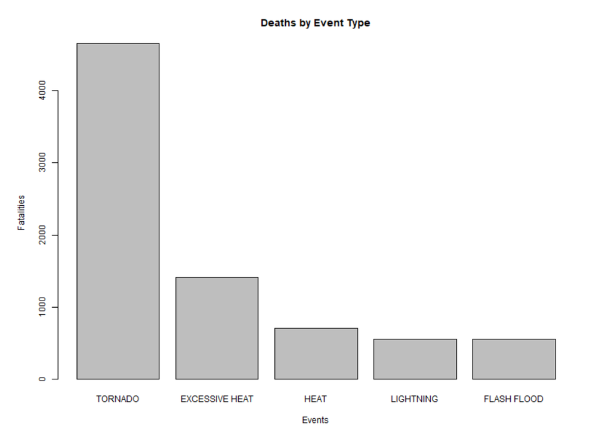

```r
  img1 <- readPNG("./plot1.png")
  grid::grid.raster(img1)
```

### Aggregate and summarizes the top 5 events with most injuries

```r
  injur <- aggregate(INJURIES~EVTYPE, storm3, sum)
  injur <- injur[with(injur, order(-INJURIES)), ]
  injur <- injur[1:5,]
  head(injur)
```

```
##             EVTYPE INJURIES
## 821        TORNADO    80084
## 166          FLOOD     6499
## 843      TSTM WIND     6452
## 126 EXCESSIVE HEAT     4354
## 457      LIGHTNING     3628
```

```r
  png("plot2.png", width=800, height=600)
  plot2 <- barplot(injur$INJURIES, names = injur$EVTYPE, xlab = "Events", ylab = "Injuries", main = "Injuries by Event Type")
  dev.off()
```

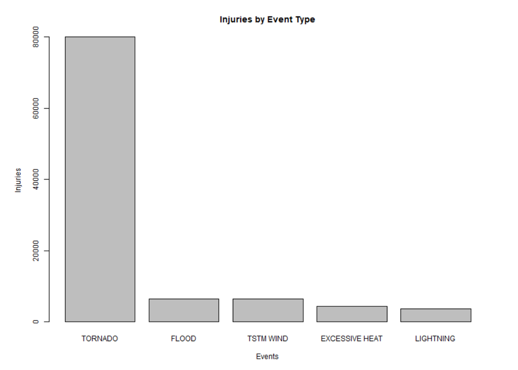

```r
  img2 <- readPNG("./plot2.png")
  grid::grid.raster(img2)
```

```r
# Set factors as numeric
storm3[,"CROPDMG"] <- as.numeric(as.character(storm3[,"CROPDMG"]))
storm3[,"CROPREPVAL"] <- as.numeric(as.character(storm3[,"CROPREPVAL"]))
storm3[,"PROPDMG"] <- as.numeric(as.character(storm3[,"PROPDMG"]))
storm3[,"PROPREPVAL"] <- as.numeric(as.character(storm3[,"PROPREPVAL"]))
```

## Mutates the dataframe by using the exponents for crop and property damage, then adds the two to determine economic cost.

```r
storm4 <- mutate(storm3, CROPTOTAL = CROPREPVAL * CROPDMG)
storm5 <- mutate(storm4, PROPTOTAL = PROPREPVAL * PROPDMG)
storm6 <- mutate(storm5, COSTTOTAL = CROPTOTAL + PROPTOTAL)

cost <- aggregate(COSTTOTAL~EVTYPE, storm6, sum)
cost <- cost[with(cost, order(-COSTTOTAL)), ]
cost <- cost[1:5,]
head(cost)
```

```
##                EVTYPE   COSTTOTAL
## 821           TORNADO 41193724517
## 405 HURRICANE/TYPHOON 19990185800
## 166             FLOOD 14671516020
## 396         HURRICANE 11961119010
## 91            DROUGHT 10705543000
```

```r
png("plot3.png", width=800, height=600)
plot3 <- barplot(cost$COSTTOTAL, names = cost$EVTYPE, xlab = "Type of Event", ylab = "Total Economic Damage", main = "Total Damage Costs by Event Type")
dev.off()
```

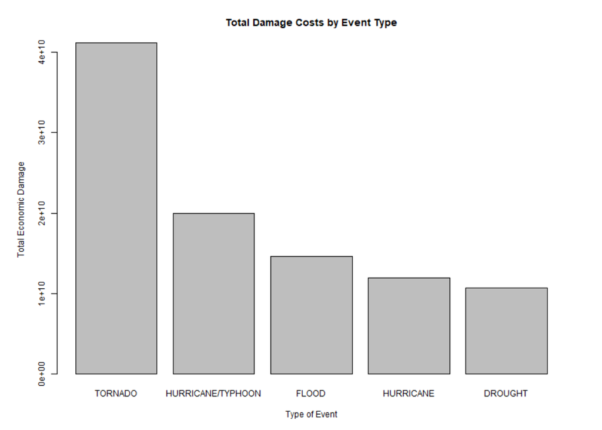

```r
img3 <- readPNG("./plot3.png")
grid::grid.raster(img3)
```